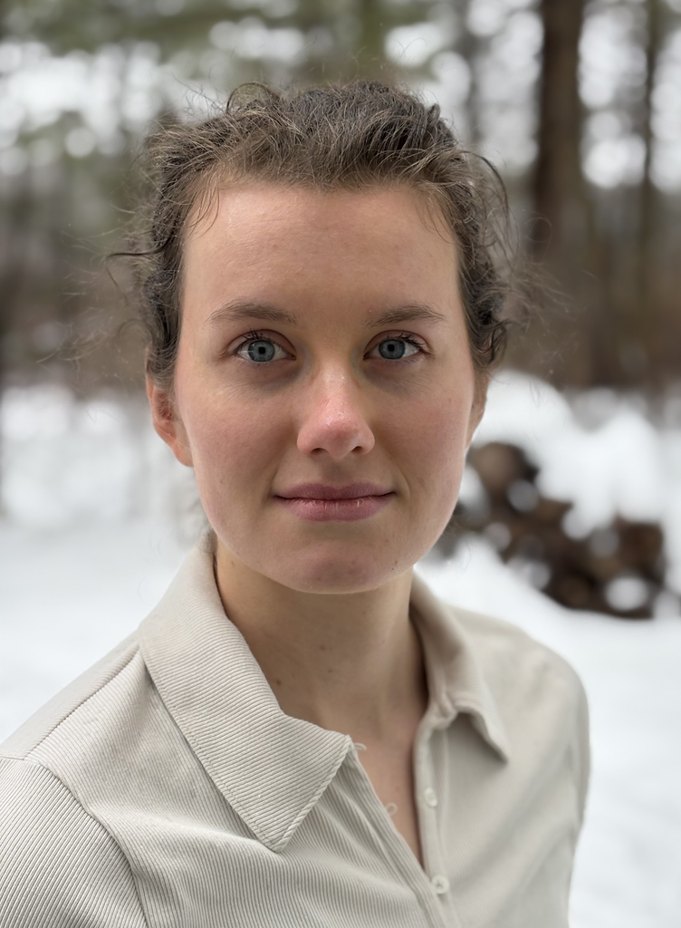

# About Me

## Goals

My goals for the next few years include:

- Strengthening my ability to analyze complex data, become proficient in statistical programming, and gain exposure to the sector of public health.
- Additionally, I am most intersted in working with projects that emphasize epidemology and biostatistics. In these domains, I aspire to use analytical and related tools to help inform decision-making of concerns in public health.

## Educaton

**Bachelors of Arts**, Psychology, University of Massachusetts Lowell

- Relevant Coursework: Biostatistics, Research Methods, Biology I

## Resume

Click here to view my resume!

## Dashboard

View My Dashboard

Thanks for checking out my web site!